# SpringHealth_Take_Home_Assessment

```r
library(knitr)
library(data.table)
library(styler)
library(dplyr)
```

## Q1 How many individuals used our platform

```r
unique_ind = length(unique(dt$member_id_hashed))
print(paste0('Number of unique individuals on platform ',unique_ind))
```

```
## [1] "Number of unique individuals on platform 1166"
```

## Q2 What is the average number of times that a member interacts with the platform

```r
avg_int=  dt %>%
  group_by(member_id_hashed) %>%
  summarise(mem_count = n()) %>%
  summarise(avg_int = mean(mem_count))
print(paste0('On average a member interacts ', round(avg_int,3), ' ~3 times'))
```

```
## [1] "On average a member interacts 2.804 ~3 times"
```

## Q3 What is the distribution of baseline PHQ9 total scores for members on the platform.

### Q3a Please include a visualization

```r
table(dt$PHQ9_score)
```

```
##
##   0   1   2   3   4   5   6   7   8   9  10  11  12  13  14  15  16  17
##  54  53 113 130 119 138 140 117 116  85  78  80  56  66  53  37  46  20
##  18  19  20  21  22  23  24  25  26
##  22  16  23  10  11  16   6   4   4
```

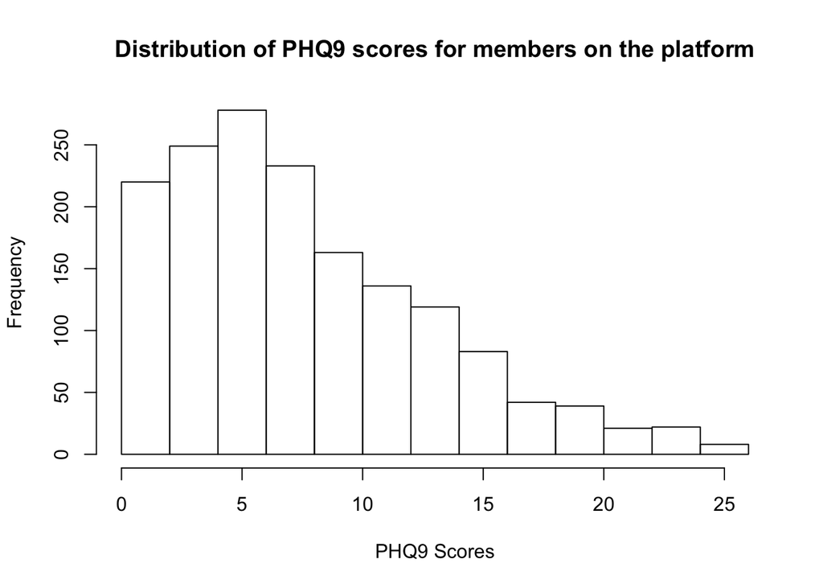

```r
hist(dt$PHQ9_score,
     main = "Distribution of PHQ9 scores for members on the platform",
     xlab = "PHQ9 Scores"
     )
```

### Q3b Please calculate summary statistics

```r
summary(dt$PHQ9_score)
```

```
##    Min. 1st Qu.  Median    Mean 3rd Qu.    Max.    NA's
##   0.000   4.000   7.000   8.108  11.000  26.000    1656
```

## Q4 What is the average change in total PHQ9 score for members using the platform

```r
avg_change = as.data.table(dt)[questionnaire_kind=='PHQ9',mean(abs(diff(PHQ9_score)))]
print(paste0('Average change in total PHQ9 scores ', round(avg_change,3)))
```

```
## [1] "Average change in total PHQ9 scores 5.382"
```

## Q5 What is the average change in total PHQ9 score for depressed individuals using the platform

```r
dep_ind = as.data.table(dt)[(PHQ9_positive==TRUE)&(questionnaire_kind=='PHQ9'),mean(abs(diff(PHQ9_score)))]
print(paste0('Average change in total PHQ9 scores for depressed individuals ', round(dep_ind,3)))
```

```
## [1] "Average change in total PHQ9 scores for depressed individuals 4.631"
```

## Q6 What is the average change in total workplace productivity (SDS_days_unproductive) for members interacting with the platform

```r
change_prod = as.data.table(dt)[(questionnaire_kind=='SDS'),mean(abs(diff(SDS_days_unproductive)), na.rm=T)]
print(paste0('Average change in total workplace productivity ', round(change_prod,3)))
```

```
## [1] "Average change in total workplace productivity 1.714"
```

## Q7 A core goal of treating depression is to improve function (e.g. SDS_days_unproductive) as well as symptoms (e.g. PHQ9_score).

### Q7a Please explore and explain the relationship between symptomatic improvement and functional improvement amongst members who interacted with the Spring platform.

```r
sds_change = as.data.table(dt)[order(assessment_created_at) & questionnaire_kind=='SDS',
                  list(change_sds = SDS_days_unproductive[1] - tail(SDS_days_unproductive, n=1)),
                  by=member_id_hashed][, mean(change_sds, na.rm = T), by = member_id_hashed]

print('Summary statistics for changes in SDS_days_unproductive')
```

```
## [1] "Summary statistics for changes in SDS_days_unproductive"
```

```r
summary(sds_change)
```

```
##                                                          member_id_hashed
##  0040127edb79766a0e8308d1ebcf836d3b5be39a15e46765aa18bc609d613da7:   1
##  0057c8f10817bcb578358cb533bf34c517dbe2a9b66b1ac30d08a235669c6fc3:   1
##  0090bd9df84a2cd4f55f89c7bbf3a40cdbb65cd037e8e023860d14abba40e4b4:   1
##  009d5573cdd71d2bf6ad49ce14aae5e2690fe3cdb914d23e4c9e0bde6b971f9c:   1
##  00acaf4db371e047188a22336128bb1b29981ab0344e74dd0235c100fe5d0040:   1
##  00bbcdd41cbce94949d3ab1d25de9ad9856f417258ab22f7c2cc5da0f303762d:   1
##  (Other)                                                         :1147
##        V1
##  Min.   :-6.00000
##  1st Qu.: 0.00000
##  Median : 0.00000
##  Mean   : 0.02614
##  3rd Qu.: 0.00000
##  Max.   : 6.00000
##  NA's   :235
```

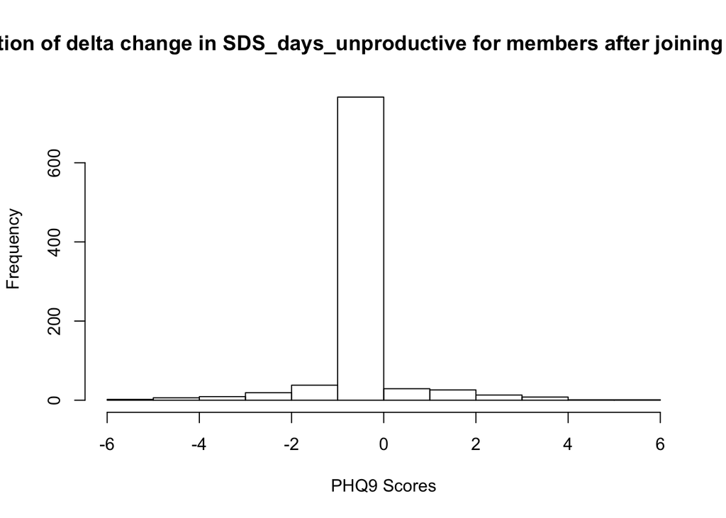

```r
hist(sds_change$V1,
     main = "Distribution of delta change in SDS_days_unproductive for members after joining the platform",
     xlab = "PHQ9 Scores")
```

```r
phq9_change = as.data.table(dt)[order(assessment_created_at, decreasing = F) & questionnaire_kind=='PHQ9',
                  list(change_sds = PHQ9_score[1] - tail(PHQ9_score, n=1)),
                  by=member_id_hashed][, mean(change_sds, na.rm = T), by = member_id_hashed]

print('Summary statistics for changes in PHQ9_score')
```

```
## [1] "Summary statistics for changes in PHQ9_score"
```

```r
summary(phq9_change)
```

```
##                                                          member_id_hashed
##  0040127edb79766a0e8308d1ebcf836d3b5be39a15e46765aa18bc609d613da7:   1
##  0057c8f10817bcb578358cb533bf34c517dbe2a9b66b1ac30d08a235669c6fc3:   1
##  0090bd9df84a2cd4f55f89c7bbf3a40cdbb65cd037e8e023860d14abba40e4b4:   1
##  009d5573cdd71d2bf6ad49ce14aae5e2690fe3cdb914d23e4c9e0bde6b971f9c:   1
##  00acaf4db371e047188a22336128bb1b29981ab0344e74dd0235c100fe5d0040:   1
##  00bbcdd41cbce94949d3ab1d25de9ad9856f417258ab22f7c2cc5da0f303762d:   1
##  (Other)                                                         :1154
##        V1
##  Min.   :-21.00000
##  1st Qu.:  0.00000
##  Median :  0.00000
##  Mean   : -0.03707
##  3rd Qu.:  0.00000
##  Max.   : 16.00000
##
```

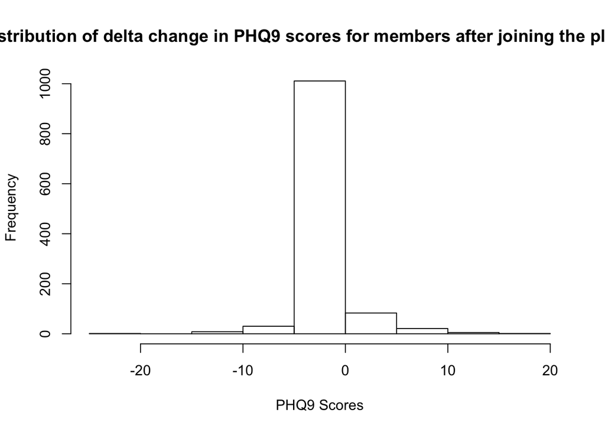

```r
hist(phq9_change$V1,
     main = "Distribution of delta change in PHQ9 scores for members after joining the platform",
     xlab = "PHQ9 Scores")
```

```r
sds_dt = as.data.table(dt)[questionnaire_kind=='SDS',c("member_id_hashed", "assessment_created_at", "SDS_days_missed", "SDS_work_impact", "SDS_home_life_impact", "SDS_days_unproductive", "SDS_social_life_impact", "SDS_risk", "SDS_positive"), with=FALSE ]


phq9_dt = as.data.table(dt)[questionnaire_kind=='PHQ9',c("member_id_hashed", "assessment_created_at",
                                                         "PHQ9_q1", "PHQ9_q2", "PHQ9_q3", "PHQ9_q4",   "PHQ9_q5","PHQ9_q6", "PHQ9_q7","PHQ9_q8","PHQ9_q9","PHQ9_q10",
              "PHQ9_risk","PHQ9_score","PHQ9_acuity", "PHQ9_positive"), with=FALSE ]

# Data is unique on member_id and assessment_created_at level
merged_dt = merge(sds_dt, phq9_dt, all.x = T, all.y=T)

# Members who have taken assessment more than once
freq_members =
  merged_dt[(is.finite(PHQ9_score)) & (is.finite(SDS_days_unproductive)) & member_id_hashed %in% merged_dt[(is.finite(PHQ9_score)) &   (is.finite(SDS_days_unproductive)), .N, by=.(member_id_hashed)][N>1]$member_id_hashed]


overall = freq_members[order(assessment_created_at, member_id_hashed, decreasing = TRUE),
                           list(overall_change_phq9 = PHQ9_score[1]-tail(PHQ9_score, n=1),
                                overall_change_sds = SDS_days_unproductive[1] - tail(SDS_days_unproductive, n=1)),
                           by=(member_id_hashed)]

print('Summary statistics for members who used platform more than once')
```

```
## [1] "Summary statistics for members who used platform more than once"
```

```r
print('Summary for SDS_days_unproductive')
```

```
## [1] "Summary for SDS_days_unproductive"
```

```r
overall_freq = as.data.table(dt)[member_id_hashed %in% freq_members$member_id_hashed,]
summary(overall_freq$SDS_days_unproductive)
```

```
##    Min. 1st Qu.  Median    Mean 3rd Qu.    Max.    NA's
##   0.000   1.000   2.000   2.241   3.000   7.000     628
```

```r
cat("\n\n")
```

```r
print('Summary for PHQ9_score')
```

```
## [1] "Summary for PHQ9_score"
```

```r
summary(overall_freq$PHQ9_score)
```

```
##    Min. 1st Qu.  Median    Mean 3rd Qu.    Max.    NA's
##   0.000   5.000   7.000   8.663  12.000  26.000     604
```

### Q7b Do you think that members benefit from interacting with the Spring platform? Why?

Members who frequented Spring Health platform had an average PHQ9_score higher than rest of the members as evident from the summary statistics above.